# Take-Home Exercise 5

Visualising and Analysing Geographic and Movement Data.

LIU Zhenglin https://example.com/norajones (SMU SCIS)https://example.com/spacelysprokets  
2022-05-30

# Importing Packages

```r
packages = c('tidyverse', 'sf', 'tmap', 'lubridate', 'clock',
             'sftime', 'rmarkdown')
for (p in packages){
  if(!require(p, character.only = T)){
    install.packages(p)
  }
}
```

# 1. Q1

Assuming the volunteers are representative of the city’s population, characterize the distinct areas of the city that you identify.

### 1.1 Importing Data

For find the social areas of the city of engagement, Ohio USA, we need to plot a map for all buildings and plot the dots which represent different building types, there are 5 types of buildings, school, apartment, employer, pub and restaurant, we choose pub and restaurant as social area and give them bigger size and change the other type buildings’ alpha to a small value to make the pub and restaurant obvious.

```r
schools <- read_sf("data/Attributes/Schools.csv",
                   options = "GEOM_POSSIBLE_NAMES=location")
buildings <- read_sf("data/Attributes/Buildings.csv",
                   options = "GEOM_POSSIBLE_NAMES=location")
pubs <- read_sf("data/Attributes/Pubs.csv",
                   options = "GEOM_POSSIBLE_NAMES=location")
apartments <- read_sf("data/Attributes/Apartments.csv",
                   options = "GEOM_POSSIBLE_NAMES=location")
employers <- read_sf("data/Attributes/Employers.csv",
                   options = "GEOM_POSSIBLE_NAMES=location")
restaurants <- read_sf("data/Attributes/Restaurants.csv",
                   options = "GEOM_POSSIBLE_NAMES=location")
```

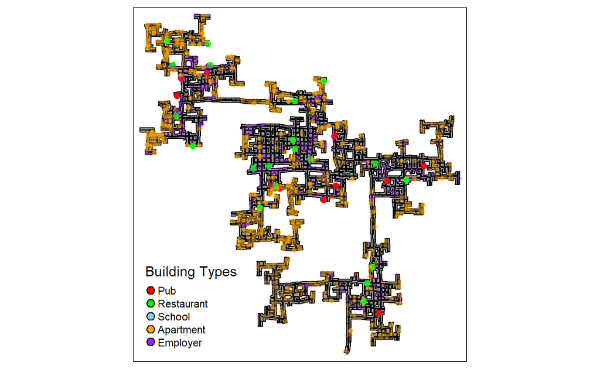

```r
types <- c('Pub', 'Restaurant','School', 'Apartment', 'Employer')
cols <- c('red', 'green', "skyblue", 'orange', 'purple')

tmap_mode("plot")

tm_shape(buildings)+
tm_polygons(col = "grey60",
           size = 1,
           border.col = "black",
           border.lwd = 1) +
tm_shape(pubs) +
tm_dots(col = "red", size = 0.2) +
tm_shape(restaurants) +
tm_dots(col = "green", size = 0.2) +
tm_shape(schools) +
tm_dots(col = "skyblue", size = 0.1, alpha = 0.2) +
tm_shape(apartments) +
tm_dots(col = "orange", size = 0.1, alpha = 0.2) +
tm_shape(employers) +
tm_dots(col = "purple", size = 0.1, alpha = 0.2) +
tm_add_legend(title = 'Building Types',
                type = 'symbol',
                labels = types,
                col = cols)
```

# 2. Q2

Where are the busiest areas in Engagement? Are there traffic bottlenecks that should be addressed?

For solving this question, we need to use participants’ logs to see the current location of them, and see the most common locations, which means the busiest area in this city.

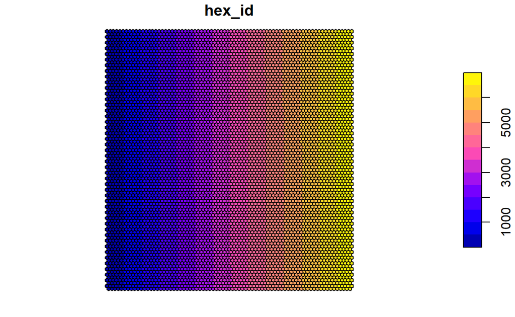

```r
hex <- st_make_grid(buildings,
                    cellsize = 100,
                    square = FALSE) %>%
  st_sf() %>%
  rowid_to_column('hex_id')
plot(hex)
```

### Importing Data

```r
logs <- read_sf("E:/data/Activity Logs/ParticipantStatusLogs1.csv",
                options = "GEOM_POSSIBLE_NAMES=currentLocation")
```

### Data Wrangling

Since we need to solve the busiest area in this city and see the traffic bottlenecks, so I tried to divided the data into weekday and weekend data, and only choose the mode equals to transport to meet the traffic requirement.

```r
logs_selected_w <- logs %>%
  mutate(Timestamp = clock::date_time_parse(timestamp,
                                     zone = "",
                                     format = "%Y-%m-%dT%H:%M:%S")) %>%
  mutate(day = clock::get_day(Timestamp)) %>%
  mutate(weekday = weekdays(Timestamp)) %>%
  filter(currentMode == "Transport") %>%
  filter(weekday == "Monday"|weekday == "Tuesday"|weekday == "Wednesday"|weekday == "Thursday"|weekday == "Friday")

logs_selected_r <- logs %>%
  mutate(Timestamp = clock::date_time_parse(timestamp,
                                     zone = "",
                                     format = "%Y-%m-%dT%H:%M:%S")) %>%
  mutate(day = clock::get_day(Timestamp)) %>%
  mutate(weekday = weekdays(Timestamp)) %>%
  filter(currentMode == "Transport") %>%
  filter(weekday == "Saturday"|weekday == "Sunday")
```

```r
write_rds(logs_selected_w,"D:/ZhenglinLIU/ISSS_608/th_ex/data/participantlog_1w.rds")
write_rds(logs_selected_r,"D:/ZhenglinLIU/ISSS_608/th_ex/data/participantlog_1r.rds")
```

```r
logs_selected_1w <- read_rds("data/participantlog_1w.rds")
logs_selected_1r <- read_rds("data/participantlog_1r.rds")
```

```r
points_in_hex_1w <- st_join(logs_selected_1w,
                            hex,
                            join= st_within) %>%
  st_set_geometry(NULL) %>%
  count(name = 'pointCount', hex_id)

points_in_hex_1r <- st_join(logs_selected_1r,
                            hex,
                            join= st_within) %>%
  st_set_geometry(NULL) %>%
  count(name = 'pointCount', hex_id)
```

```r
hex_combined_1w <- hex %>%
  left_join(points_in_hex_1w,
            by = 'hex_id') %>%
  replace(is.na(.), 0)

hex_combined_1r <- hex %>%
  left_join(points_in_hex_1r,
            by = 'hex_id') %>%
  replace(is.na(.), 0)
```

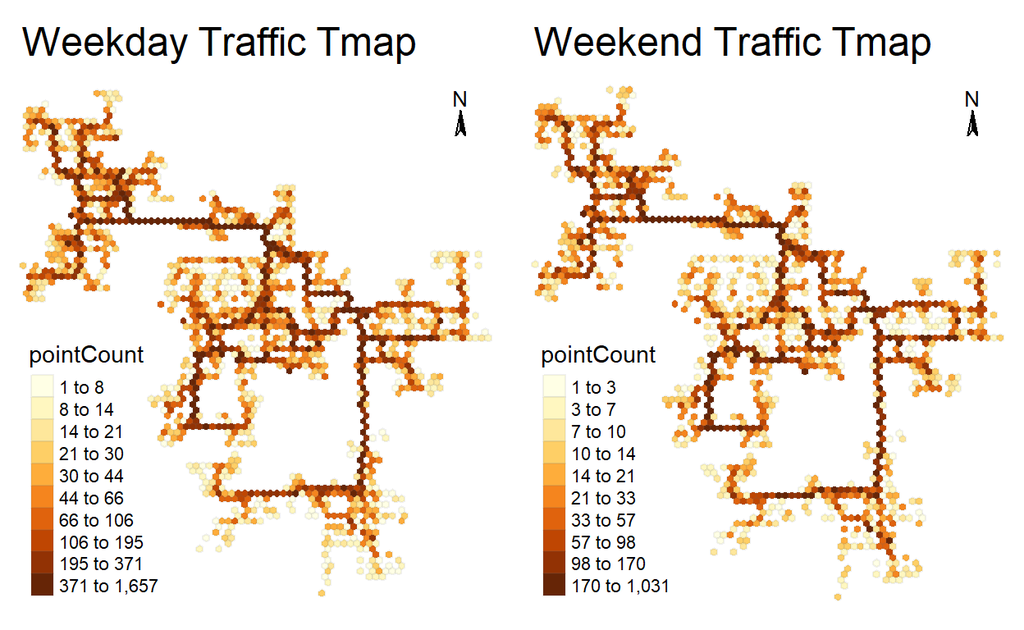

```r
tm_w <- tm_shape(hex_combined_1w %>%
           filter(pointCount > 0))+
  tm_fill("pointCount",
          n = 10,
          style = "quantile") +
  tm_borders(alpha = 0.1) +
  tm_layout(main.title = 'Weekday Traffic Tmap',
            frame = FALSE) +
  tm_compass(size = 1,
             position = c('right', 'top'))

tm_r <- tm_shape(hex_combined_1r %>%
           filter(pointCount > 0))+
  tm_fill("pointCount",
          n = 10,
          style = "quantile") +
  tm_borders(alpha = 0.1) +
  tm_layout(main.title = 'Weekend Traffic Tmap',
            frame = FALSE) +
  tm_compass(size = 1,
             position = c('right', 'top'))

tmap_arrange(tm_w, tm_r)
```

According to the chart above, we can draw the conclusion is that, no matter weekdays or weekends, there are still some main roads area very busy, most of them are in the middle area. Compared with weekdays, the number of travel is less, so the traffic situation is slightly better than weekdays.